# Topic Modeling State of the Union Speeches

Annamaria Prati

June, 2016

In an election year, when we consider what challenges the next president will inevitably face, it could be helpful to look at recent presidencies to see if there are consistent themes for a president’s concerns and goals. One rather succinct event where these themes are outlined is in the annual State of the Union addresses (often referred to as SOTUs). Theoretically, if one goes too far back in time, the world stages might no be comparable, and the themes might not be as meaningful. Therefore, as a starting point, I considered topic modeling SOTUs from the end of the Cold War (which I am dating as 1990) to today. I got the text from the SOTUs from the American Presidency Project at UC Santa Barbara, and included all SOTUs from 1990 through 2016 (excluding speeches that the project flagged as not “true” SOTU speeches at the beginning of a new administration, i.e. Clinton’s 1993 speech, Bush’s 2001 speech, and Obama’s 2009 speech) for a total of 24 speeches.

```r
setwd("~/Desktop/portfolio/topic_modeling_SOTU")

stopifnot(require(quanteda))
```

```
## quanteda version 0.9.6.9
##
##
##
```

```r
docs <- textfile("~/Desktop/portfolio/topic_modeling_SOTU/*.txt", cache = FALSE)
summary(corpus(docs), 5)
```

```
## Corpus consisting of 24 documents, showing 5 documents.
##
##      Text Types Tokens Sentences
##  1990.txt  1208   4390       198
##  1991.txt  1299   4550       226
##  1992.txt  1501   5841       320
##  1994.txt  1751   8349       396
##  1995.txt  1924  10260       460
##
## Source:  /Users/Mia/Desktop/portfolio/topic_modeling_SOTU/* on x86_64 by Mia
## Created: Thu Jun  2 15:38:58 2016
## Notes:
```

```r
docs_corpus <- corpus(docs)

dfm_docs <- dfm(docs_corpus, ignoredFeatures=c("will", stopwords("english")))
```

```
## Creating a dfm from a corpus ...
##    ... lowercasing
##    ... tokenizing
##    ... indexing documents: 24 documents
##    ... indexing features: 8,921 feature types
##    ... removed 167 features, from 175 supplied (glob) feature types
##    ... created a 24 x 8755 sparse dfm
##    ... complete.
## Elapsed time: 0.716 seconds.
```

```r
dim(dfm_docs)
```

```
## [1]   24 8755
```

Now I am ready to analyze the speeches. What are the top 25 words in the SOTUs?

```r
topfeatures(dfm_docs, 25)
```

```
##    people   america       can       new        us      must       now
##       661       615       591       580       528       518       485
##  american      work     years     every     world      year americans
##       437       426       413       412       402       390       388
##      make  congress       one      help   country      know   tonight
##       385       358       356       334       314       308       295
##      time      jobs      need  children
##       295       281       273       269
```

Unsurprisingly, words related to “America” are the most common, as well as words related to the economy and jobs, foreign affairs, and dpossibly domestic government. It is interesting that the word “help” is used so frequently, and it is unclear what is meant by that. For a closer look, I looked at the original corpus to look at the words in context:

```r
kwic(docs_corpus, "help", window = 5)
```

[output not shown]

As might be expected, “help” is used in a wide variety of contexts, from foreign policy (“help Ukraine defend its democracy” (2016)) to philanthropy (“help one hungry child” (1991)) to the economy (“help one million young Americans work” (1996)) to generally inspirational (“help us reach that goal” (2005)).

More visually, here are the top words:

```r
stopifnot(require(RColorBrewer))
```

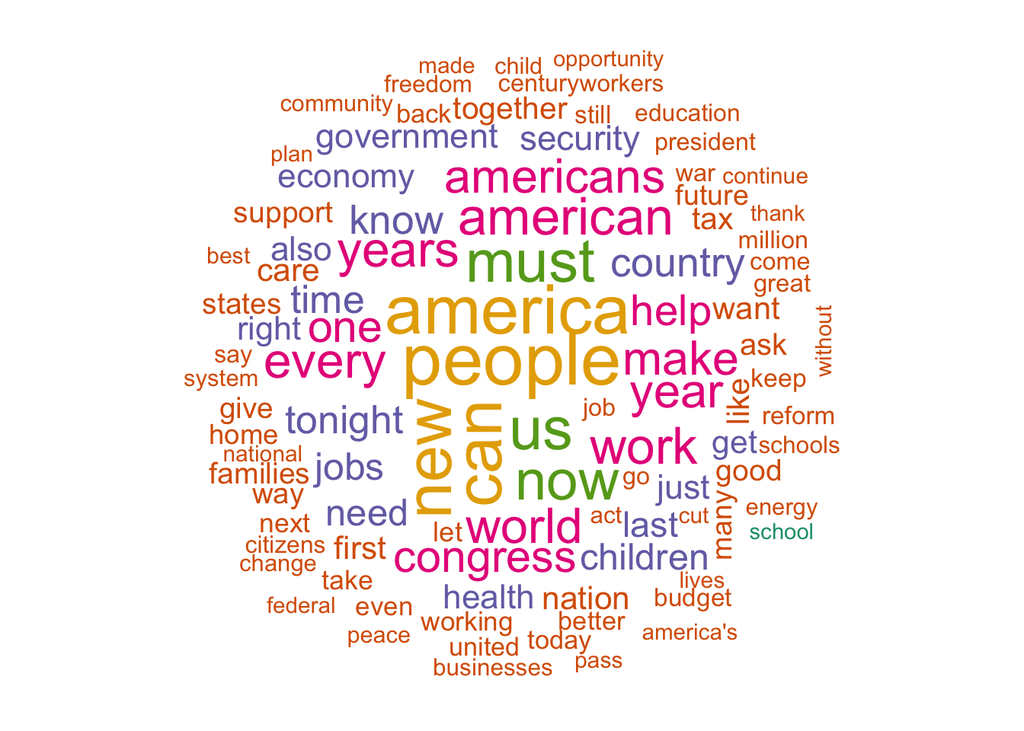

```r
set.seed(1234)

plot(dfm_docs, min.freq = 100, max.words = 100, colors = brewer.pal(6, "Dark2"), scale = c(3, .5), random.order = FALSE)
```

Returning to the original question, what are the consistent issues that a new president would have to face? Qualitatively from above, the economy is a looming issue, along with world affairs, domestic governance, and families. More quantitatively, we can examine the themes through a topic model:

```r
quant_dfm <- dfm(docs_corpus, ignoredFeatures=c("will", stopwords("english")), stem = TRUE, verbose = FALSE)

stopifnot(require(topicmodels))
seed <- 1234

fit <- LDA(convert(quant_dfm, to = "topicmodels"), k = 25, seed = seed)
terms <- get_terms(fit, 5)
terms
```

```
##      Topic 1    Topic 2    Topic 3   Topic 4    Topic 5 Topic 6
## [1,] "new"      "america"  "peopl"   "american" "must"  "america"
## [2,] "year"     "world"    "nation"  "work"     "peopl" "american"
## [3,] "america"  "everi"    "weapon"  "help"     "can"   "terrorist"
## [4,] "american" "american" "countri" "america"  "plan"  "secur"
## [5,] "make"     "year"     "year"    "job"      "know"  "world"
##      Topic 7    Topic 8 Topic 9    Topic 10 Topic 11  Topic 12
## [1,] "american" "peopl" "work"     "year"   "must"    "america"
## [2,] "job"      "work"  "challeng" "can"    "america" "must"
## [3,] "year"     "year"  "american" "new"    "year"    "nation"
## [4,] "america"  "can"   "peopl"    "peopl"  "everi"   "american"
## [5,] "get"      "new"   "children" "us"     "now"     "secur"
##      Topic 13   Topic 14   Topic 15   Topic 16   Topic 17   Topic 18
## [1,] "year"     "year"     "us"       "peopl"    "year"     "american"
## [2,] "must"     "america"  "america"  "year"     "new"      "must"
## [3,] "american" "peopl"    "american" "work"     "america"  "work"
## [4,] "secur"    "american" "iraq"     "american" "can"      "now"
## [5,] "centuri"  "must"     "can"      "care"     "american" "thank"
##      Topic 19  Topic 20   Topic 21   Topic 22   Topic 23   Topic 24
## [1,] "america" "ask"      "american" "year"     "job"      "american"
## [2,] "can"     "year"     "iraq"     "american" "now"      "year"
## [3,] "peopl"   "new"      "world"    "now"      "year"     "us"
## [4,] "help"    "help"     "america"  "peopl"    "work"     "america"
## [5,] "health"  "children" "drug"     "work"     "american" "work"
##      Topic 25
## [1,] "world"
## [2,] "american"
## [3,] "nation"
## [4,] "america"
## [5,] "us"
```

```r
topic<- topics(fit, 3)
topic
```

```
##      1990.txt 1991.txt 1992.txt 1994.txt 1995.txt 1996.txt 1997.txt
## [1,]        2       25        5       16        8        9       11
## [2,]        3       20        2       23        4       11        2
## [3,]       22       23       18       22        5       17       13
##      1998.txt 1999.txt 2000.txt 2002.txt 2003.txt 2004.txt 2005.txt
## [1,]       17       13       20        6        3       19       12
## [2,]        5       18       18       20       21       21       21
## [3,]        8       16       13       10        2        2        2
##      2006.txt 2007.txt 2008.txt 2010.txt 2011.txt 2012.txt 2013.txt
## [1,]       12       15       14       22       10        7       23
## [2,]        6       21       12        7        7        8        1
## [3,]       21       12       21        2        2        5        9
##      2014.txt 2015.txt 2016.txt
## [1,]        4        1       24
## [2,]        1       22        1
## [3,]       23       23        2
```

```r
most_frequent <- which.max(tabulate(topic))
most_frequent
```

```
## [1] 2
```

Of the top 25 topics, many include some variant of “America”, unsurprising since these are SOTUs. Several seem to be related to the economy and jobs (using terms like “work” and “job”), and several others seem to be related to national security and foreign policy, including the war in Iraq but not the war in Afghanistan (using terms like “weapon,” “nation,” “world,” “iraq,” and “secure”).

To conclude, based on themes from the SOTU addresses since the Cold War, the future president will have to address jobs and the economy and then issues of national security and war. Under both subject headings, the future president will need to support American pride and nationalism by rhetorically reaffirming America’s place in the world order and the importance of Americans’ relationships to each other.